# 환경 빅데이터 뉴스레터 : 2023년 9월

sung won kang

2024-01-11

## Summary

> 2023년 9월에 게시된 네이버 환경뉴스를 분석한 결과 환경오염물질의 배출, 후쿠시마 원전 오염수 방류, 기후변화, 폐기물 관련 키워드가 빈번하게 출현하였다.환경무 문헌의 키워드에서도 환경오염물질의 배출, 기후변화, 폐기물 관련 키워드가 빈번하게 출현하여 후쿠시마 원전 오염수 방류를 제외한 이슈에 대해서는 네이버 환경뉴스 키워드와 조응하는 경향이 있었다. 환경부 문헌에서는 자연환경 및 환경정책 관련 키워드가 발견되었으나, 네이버 환경뉴스에서는 이와 관련된 키워드가 빈번하게 출현하지 않았다.

텍스트 분석 바로가기

> 2023년 8월 1주차에는 chlorophyll-a 예측치가 25$\mu g/m^3$ 이상이어서 녹조 농도가 높을 것으로 예측되는 측정소는 존재하지 않았다.

녹조 예측 바로가기

> 2014-2022년 간 광역자치단체 단위 PM10 농도와 1인당 소비 및 평균소비성향간의 관계를 분석한 결과 , PM10의 농도와 소비와의 관계는 일률적이지 않았다. 1인당 소비는 PM10 농도와 약한 음의 상관관계가 있었지만, 평균소비성향과는 약한 양의 상관관계가 있었다. 온실가스 배출량은 2019년, 2020년 2년에 걸쳐 감소하였으며, GDP 대비 배출량은 2012년 이후 지속된 감소 추세를 2019년, 2020년에도 유지하였다.

대기오염,기후변화,탄소중립 질문기반DB 바로가기

## 1. 텍스트분석

- 한국환경연구원 텍스트 수집 도구는 2023년 9월 30일까지 네이버 기사 데이터와 환경부 문헌 데이터를 제공한다. 아래 뉴스레터에서는 2023년 9월 1일을 기점으로 30일 이전까지 수집한 자료를 사용한다.

#### A. Text 데이터

분석 대상 Text Data는 다음 두 종류의 문헌을 자료이다.

1. NAVER 환경 뉴스 : 2023년 9월 1일-2023년 9월 30일 NAVER 뉴스> ‘사회’ >‘환경’ 부문에 게시된 뉴스
2. 환경부 문건 : 2023년 9월 1일-2023년 9월 30일 환경부홈페이지에 게시된 환경부 보도자료 및 e-환경뉴스

’NAVER 환경 뉴스’는 환경정책의 수요자인 국민의 환경과 관련된 관심사를 전달하는 텍스트 자료이다. 그리고 ’환경부 문건’은 환경정책의 공급자인 환경부의 관심사를 전달하는 텍스트 자료이다. 이 두 자료의 키워드를 비교하여 환경정책 공급자의 관심사가 환경정책 수요자의 관심사에 조응하는지 여부를 점검한다.

#### B. 키워드 빈도분석

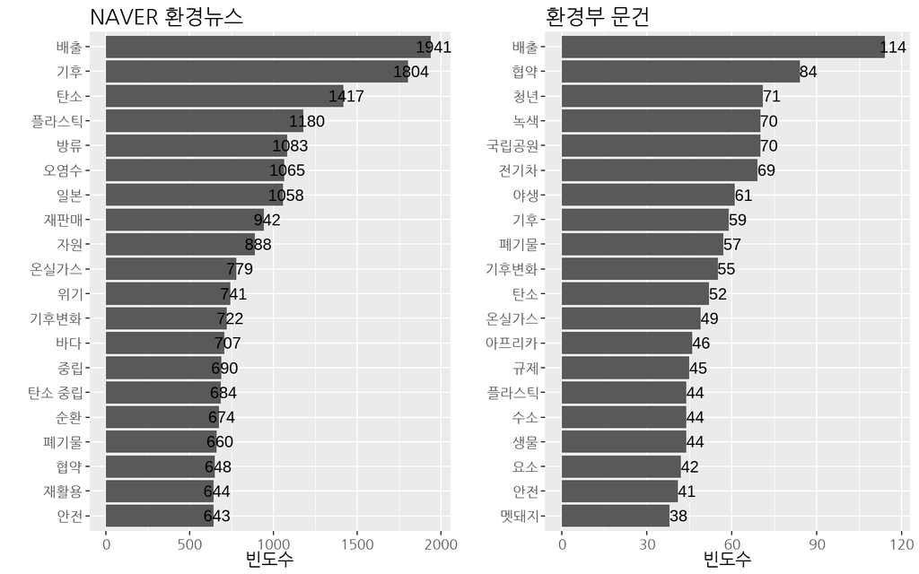

눈에 띄는 특징은 다음과 같이 정리할 수 있다.

- 첫째, 네이버 환경뉴스에는 빈도수가 높은 키워드와 환경부 문건에서 빈도수가 가장 높은 키워드가 ’배출’로 일치하였다. 네이버 환경뉴스와 환경부 문건 모두 ’배출’이 제목에 포함된 문건은 온실가스를 포함한 다양한 환경오염물질 배출과 관련된 문건들이었다.
- 둘째, 네이버 환경뉴스에는 빈도수가 높은 상위 20개 키워드 중 ‘오염수’,‘일본’,‘방류’,‘안전’이 발견되어 후쿠히마 원전 가동과 관련된 관심이 유지되었음을 시사하였으나, 환경부 문헌에서는 이에 상응하는 키워드는 발견되지 않았다. 이는 2023년 8월까지 지속된 현상이 유지되고 있음을 시사한다. 환경부 문건에서도 ’안전’ 키워드는 발견되었지만 이를 제목에 포함하는 환경부 문건은 후쿠시마 원전 가동과는 관련이 없었다.
- 셋째, 네이버 환경뉴스에는 빈도수가 높은 상위 20개 키워드 중 ‘기후’,‘탄소’,‘온실가스’,‘기후변화’,‘탄소 중립’와 같이 기후변화 관련 키워드가 발견되었으며 환경부 보도자료에도 이에 상응하는 ’녹색’,‘기후’, ‘기후변화’,‘탄소’,‘온실가스’,‘전기차’,’수소’와 같은 키워드가 발견되었다.
- 넷째, 네이버 환경뉴스에는 빈도수가 높은 상위 20개 키워드 중 ‘플라스틱’,‘자원’,‘순환’,‘폐기물’,‘재활용’과 같이 폐기물 관련 키워드가 발견되었으며 환경부 보도자료에도 이에 상응하는 ’폐기물’,’플라스틱’과 같은 키워드가 발견되었다.
- 다섯째, 네이버 환경뉴스에는 빈도수가 높은 상위 20개 키워드 중 공공기관, 민간, 국가 간 환경 협력을 나타내는 ‘협약’ 키워드가 발견되었으며 환경부 보도자료에도 이에 상응하는 ’협약’키워드가 발견되었다.
- 여섯째, 환경부 문건의 빈도수 상위 20개 키워드 중에는 ‘국립공원’,‘아프리카’(아프리카 돼지열병),‘야생’,‘생물’,‘멧돼지’와 같이 생태계와 관련된 키워드, 그리고 ’청년’,‘규제’,‘요소’(요소수공급) 와 같이 다양한 환경정책 관련 키워드가 발견되지었지만, 네이버 환경뉴스에서는 이에 상응하는 키워드가 발견되지 않았다.

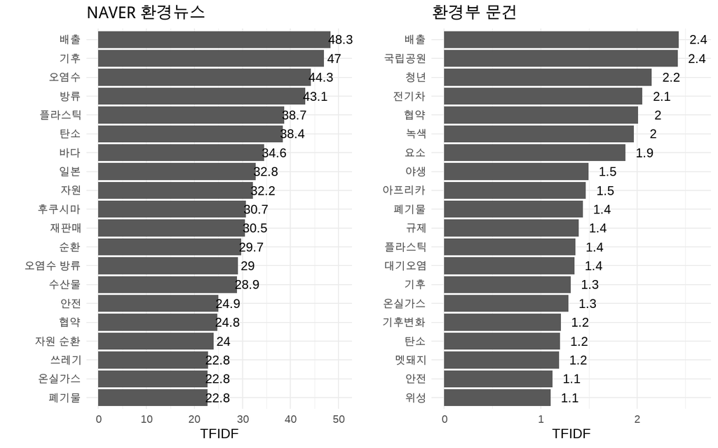

이와 같은 경향은 TF_IDF 값이 높은 20개의 키워드를 추출하여 비교하여도 확인된다. Figure 2는 TF_IDF를 기준으로 추출한 상위 20개 키워드의 TF_IDF 값을 보여준다. Figure 2에서도 확인할 수 있듯이

- ‘배출’ 키워드는 NAVER 뉴스와 환경부 문건에서 가장 TF_IDF 값이 큰 키워드이다.
- ‘오염수’,‘방류’,‘바다’,‘일본’,‘후쿠시마’,‘오염수 방류’ 등 후쿠시마 원전 오염수 방류 관련 키워드는 NAVER 뉴스에서만 찾아볼 수 있다.
- ‘기후’, ‘탄소’,‘온실가스’와 같은 NAVER 뉴스의 키워드와 ’전기차’,‘녹색’,‘기후’,‘온실가스’,’기후변화’와 같은 환경부 문건의 키워드는 기후변화와 대한 민간의 관심과 환경부의 관심이 상호 일치함을 보여준다.
- ‘플라스틱’,‘자원’,‘순환’,‘자원 순환’,‘쓰레기’,‘폐기물’과 같은 NAVER 뉴스의 키워드와 ’폐기물’,’플라스틱’과 같은 환경부 문건의 키워드는 폐기물에 대한 민간의 관심과 환경부의 관심이 상호 일치함을 보여준다.
- ‘국립공원’,‘야생’,‘아프리카’,‘멧돼지’와 같은 자연환경과 관련된 키워드, ’청년’,’규제’와 같은 환경정책 관련 키워드는 환경부 문건에서만 찾아 볼 수 있다.

#### C. 키워드 관련 뉴스

네이버 환경뉴스 키워드와 환경부 문건 키워드간의 차이의 원인을 파악하기 위해서 두 문헌에서 단순빈도가 가장 높은 10개 키워드 중 서로 상이한 키워드가 포함된 문헌의 제목들을 비교하였다.

- 네이버 환경뉴스에서 단순빈도가 높은 10개 키워드 중 환경부 문건의 단순빈도가 높은 20개 키워드에 포함되지 않은 키워드는 [방류, 오염수, 일본, 재판매, 자원]이다. 이들 중 ‘자원’은 자원순환에 관련된 키워드로서 환경부 문헌의 ’폐기물’, ‘플라스틱’ 등 폐기물 관련 키워드들과 연관이 있다.
- 환경부 문헌에서 단순빈도가 높은 10개 키워드 중 네이버 환경뉴스에서 단순빈도가 높은 20개 키워드에 포함되지 않은 키워드는 [청년, 녹색, 국립공원, 전기차, 야생]이다. 이들 중 ‘녹색’,‘전기차’는 기후변화에 관련된 키워드로서 네이버 환경뉴스의 ’기후’, ‘탄소’ 등 기후변화 관련 키워드들과 연관이 있다.
1. ‘방류’,‘오염수’, ’일본’을 제목에 포함하는 기사들은 후쿠시마 제1원자력발전소 오염수 방류와 관련된 기사로 파악되었다. ’재판매’를 제목에 포함하는 기사는 존재하지 않았다.

| Title |
| --- |
| 중국 수산물값 외려 상승…“日오염수 8개월 후에나 中연안 도착” |
| ‘원전 오염수 제주도민 피해 日정부에 구상권’ 조례 추진 |
| 日오염수 방류 이후…삼중수소 기준치 이하·中 전면금수 반발 |
| 후쿠시마 원전 오염수 방류 관련 정부 일일 브리핑 |
| 박구연 국무조정실 1차장, 후쿠시마 원전 오염수 방류 데이터 분석 설명 |
| 후쿠시마 원전 오염수 방류 데이터 분석 설명하는 박구연 1차장 |
| 정치·이념 공방에 묻혀버린 숨은 노력들 [오염수 방류⑤] |
| 10명 중 7명 “후쿠시마 오염수 저지하는 불매운동 참여하겠다” |
| ‘오염수 방류 반대’ 日시민단체, 기시다·도쿄전력 사장 고발 |
| 日오염수 방류 이후…삼중수소 기준치 이하·中 전면금수 반발(종합2보) |
| 후쿠시마 오염수 방류 여론조사 결과는? |
| 日오염수 방류 이후…삼중수소 기준치 이하·中 전면금수 반발(종합) |
| 후쿠시마 오염수 방류 관련 여론조사 결과발표 기자회견 |
| 환경단체 “국민 72.4% 오염수 투기 반대…불매운동 해야” |
| “日원전 오염수 방류, 계획과 다르게 진행되면 IMO서 문제제기” |

환경부 문헌에서 가장 빈도가 높은 10개 키워드 중 네이버 뉴스에서 가장 빈도가 높은 키워드 20개에 포함되지 않은 키워드는 ‘청년’,‘녹색’,‘국립공원’,‘전기차’,‘야생’ 이다. 이 중 ‘녹색’,’전기차’는 네이버 뉴스의 키워드 중 ’기후’에 조응한다. 그 외의 키워드에 조응하는 네이버 뉴스 키워드는 찾아보기 어렵다. 2023년 9월 1일부터 9월 30일까지 게시된 환경부 문헌 중 이들 키워드를 제목에 포함하는 환경부 문헌은 다음과 같다.

1. ‘청년’ 을 제목에 포함하는 문헌은 3건으로 환경정책에 청년들의 의견을 반영하거나 청년들에게 참여 기회를 제공하는 정책 관련 문헌이었다.

| Title |
| --- |
| 청년의 눈으로 정책을 봅니다. 정부 정책의 동반자 청년보좌역을 채용합니다. |
| 청년이여 녹색기회를 잡아라 |
| 국가생물다양성전략 수립에 청년 목소리 듣는다 |

2. ‘국립공원’,‘야생’ 을 제목에 포함하는 문헌은 8건이었는데 5건은 국립공원 이용 관련 문헌이었고,1건은 아프리카돼지열병 관련 문헌이었으며, 2건은 야생조류 조류인플루엔자 관련 문헌이었다. 모두 자연환경 관련 문헌이었다.

| Title |
| --- |
| 국립공원에서 저탄소·친환경 탐방 함께해요…탄소중립 주간 운영 |
| ‘길 따라 가을 속으로’ 국립공원 가을철 역사문화 체험 과정 운영 |
| 경북지역 야생멧돼지 아프리카돼지열병 차단 총력 대응 |
| 야생포유류 조류인플루엔자 예방 국민의 적극적인 신고 필요 |
| 올겨울 야생조류 조류인플루엔자 대응 위해 관계기관 담당자 정보 공유 |
| 국립공원 안전한 탐방 위해 야생동물과 거리 두세요 |
| 직영주차장 무료이용 등 추석연휴 국립공원 이용 지원 대책 추진 |
| 함께 거니는 삵과 오소리 등 국립공원 희귀영상 공개 |

#### D. 정리

2023년 9월 1일-2023년 9월 30일 게시된 네이버 환경뉴스와 환경부 문헌을 비교한 결과를 요약하면 다음과 같다.

1. 네이버 기사에는 후쿠시마 원전 오염수와 관련된 키워드가 출현하였지만 환경부 문헌에서는 이에 조응하는 키워드가 발견되지 않았다. 이는 2023년 8월까지의 키워드 분석 결과와 일관된 결과이다.
2. 환경부 문헌에는 자연환경 및 환경정책 관련 키워드가 출현하였지만 네이버 뉴스에서는 이에 조응하는 키워드가 발견되지 않았다.
3. 네이버 기사와 환경부 문헌 모두 환경오염물질의 배출, 기후변화, 그리고 폐기물 관련 키워드가 출현하였다. 이는 기후변화 및 폐기물과 관련된 민간의 관심과 정부의 개입이 조응하고 있음을 시사한다.

## 2. 녹조예측

#### A. Data

분석 대상 Data는 2023년 “환경 빅데이터 분석 및 서비스 개발” 과제에서 구축한 녹조 예측 CNN 모형의 Chlorophyll-a 예측치이다. 이 모형은 2016년부터 2022년까지의 수질오염도 자료를 이용하여 1주 이후의 Chlorophyll-a 농도를 예측한다. 예측의 대상은 안정적으로 물환경정보시스템의 API 계정을 통해 데이터를 확보할 수 있는 16 수질오염자동측정소이다.

- 예측 대상 측정소 : 안동1, 안동4, 반변천4, 금호강8, 곡교천2, 고령, 구포, 학성, 적성, 물금, 내성천5, 남강7, 남지, 논산천4, 상주3, 산곡

#### B. 예측결과

각 측정소에서 예측 가능한 최근 시점에 Chlorophyll-a 예측치가 25$\mu g/m^3$ 이상이어서 녹조 농도가 높을 것으로 예측되는 측정소는 아래의 표에 수록한 0개 측정소이다. 아래 표의 각각의 행에 수록된 변수의 정의는 다음과 같다.

- 측정소 : 예측의 대상인 측정소
- 예측시점 : 예측 가능한 최근 시점
- 예측치 : 예측시점의 Chlorophyll-a 예측치

| 측정소 | 예측치 | 예측시점 |
| --- | --- | --- |

위의 표에 수록된 측정소의 위치를 지도에 표시하면 다음과 같다. 점의 크기가 클 수록 예상 녹조 농도가 높은 측정소이다.

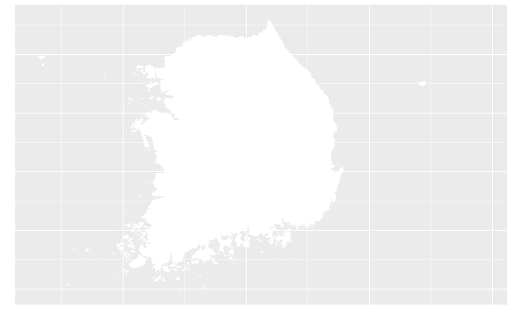

**그림 2-1.녹조 위험 예고 지역**

## 3. 질문기반DB

3.질문기반DB의 내용은 KEI와 서울대학교 행정대학원이 공동으로 개발한 질문중심 DB에 기재된 내용에서 발췌하였다. 원자료는 이하에 기재한 웹사이트로부터 확인할 수 있다.

1. A.대기오염: https://147.47.206.193/SASVisualAnalytics/?reportUri=%2Freports%2Freports%2Ffec6424f-fa2c-4078-8ba5-31e491af1137&sectionIndex=0&sso_guest=true&sas-welcome=false
2. B.기후변화: https://147.47.206.193/SASVisualAnalytics/?reportUri=%2Freports%2Freports%2F23681dc6-2802-4b43-bc8e-636d1154733a&sectionIndex=0&sso_guest=true&sas-welcome=false
3. C. 탄소중립
- 한국: https://lookerstudio.google.com/reporting/3d1b7550-d95b-4cef-aa6b-13f66ca6a5e4
- 국제: https://lookerstudio.google.com/reporting/5049004e-23dc-4da8-a7dc-040c95ce30a3

#### A. 대기오염

그림 3-1의 왼쪽 그래프는 2014년부터 2022년까지 광역지자체 연평균 PM10농도와 1인당소비 간의 상관관계를 보여주고, 오른쪽 그래프는 같은 기간 광역지자체 연평균 PM10농도와 평균소비성향 간의 관계를 보여준다. 그림 3-1은 PM10 농도와 1인당 소비 간에는 약한 음의 상관관계가 있지만, PM10 농도와 평균소비성향 간에는 미약한 양의 상관관계가 있음을 보여준다. 평균소비성향이 소득 중에서 소비가 차지하는 비중임을 고려하면, 그림 3-1의 왼쪽 그래프는 PM10 농도가 높은 광역지자체의 소득 수준이 낮은 경향이 있음을 암시한다. 그림 3-1에서 관찰되듯이, 미세먼지가 민간 소비에 미치는 영향은 일률적이지 않다.

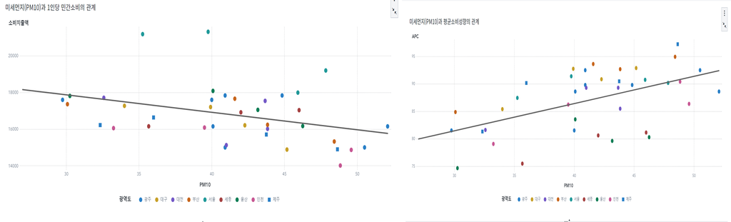

**그림 3-1 광역지자체 단위 PM10 농도와 1인당 소비 및 평균소비성향과의 관계(2014-2020)**

#### B.기후변화

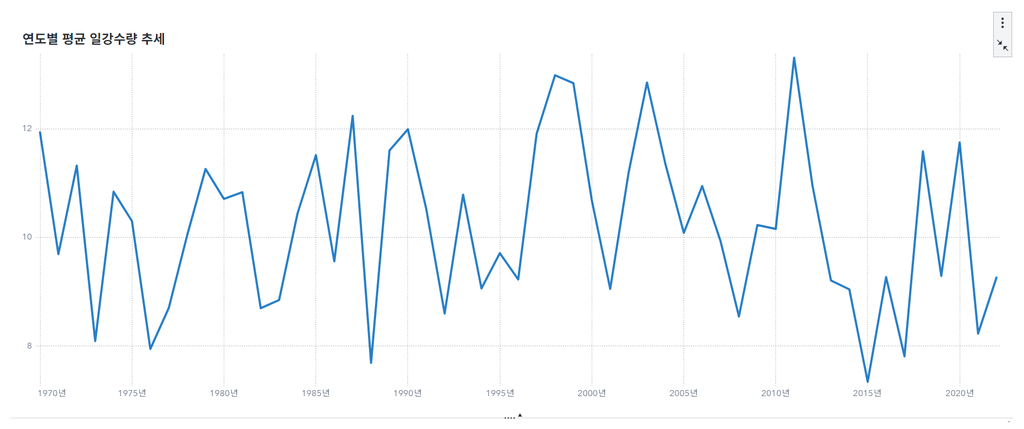

**그림 3-2 연도별 평균 일강수량 추이**

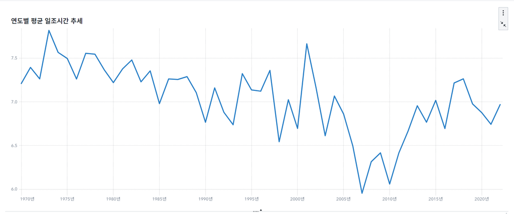

**그림 3-3 연도별 평균 일조시간**

#### C.탄소중립

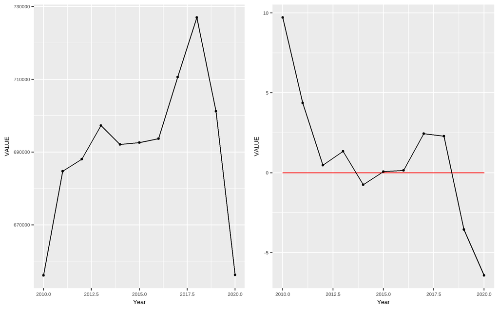

**그림 3-4 한국 온실가스 배출량 추이(2010-2020)**

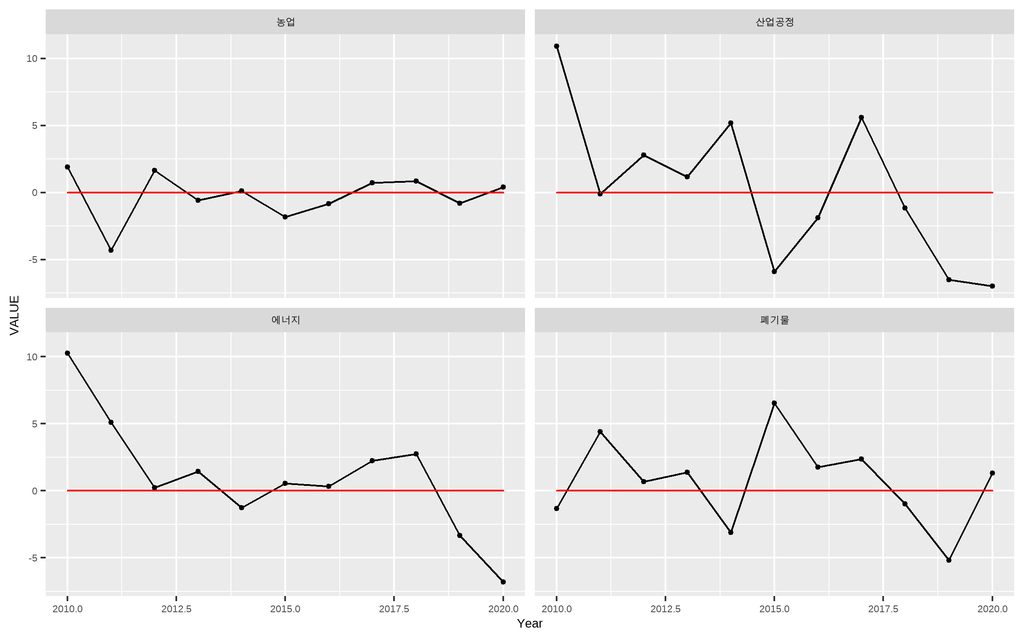

**그림 3-5 한국 부문별 온실가스 배출량 증감률 추이 (2010-2020)**

그림 3-6은 한국의 2010년 이후 GDP 대비 배출량의 추이를 보여준다. 총배출량의 추이와는 달리 2011년을 고비로 GDP 대비 배출량은 감소세가 지속되고 있다. 이는 한국의 경우 2012년 이후에는 ‘탈동조화’ 현상이 나타나고 있음을 시사한다.

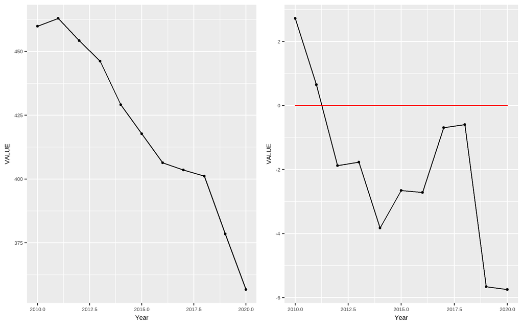

**그림 3-6 GDP 대비 배출량 및 증감률 추이**